# Advanced ggplot2: In class

Author

Paul M. Magwene

## Goal

The goal of today’s class session is to learn how to produce customized and polished data visualizations using the `ggplot2` package. Generating basic data visualizations in ggplot can be relatively easy, but tweaking and customizing a figures to the point where it’s “publication quality” can often involve quite a bit of additional work such as figuring out what key aesthetic properties to tweak, generating derived data for annotations, etc.

To provide you with experience in producing publication quality figures, you’ll work with your fellow classmates with the aim of reproducing the figure shown below.

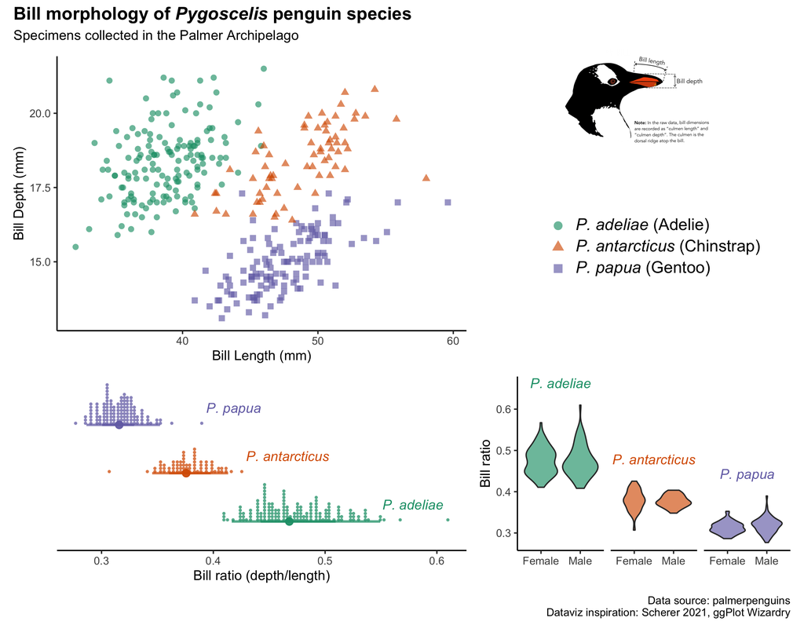

Figure 1: A multi-part figure based on morphological measurements from the palmerpenguins library.

## Subplot 1

Description: A bivariate scatter plot depicting the joint distribution of bill variables in the Palmer penguins data set

Key tweaks:

- Plot uses both shape and color of points to distinguish between species
- Uses RColorBrewer color scheme “Dark2”
- Legend text and symbols increased in size for readability (see `guides()` and `guide_legend()`)
- Legend labels to have latinate names and those names are italicized. Achieved using `ggtext::element_markdown()` and changing the `legend.text` parameter in `theme()`

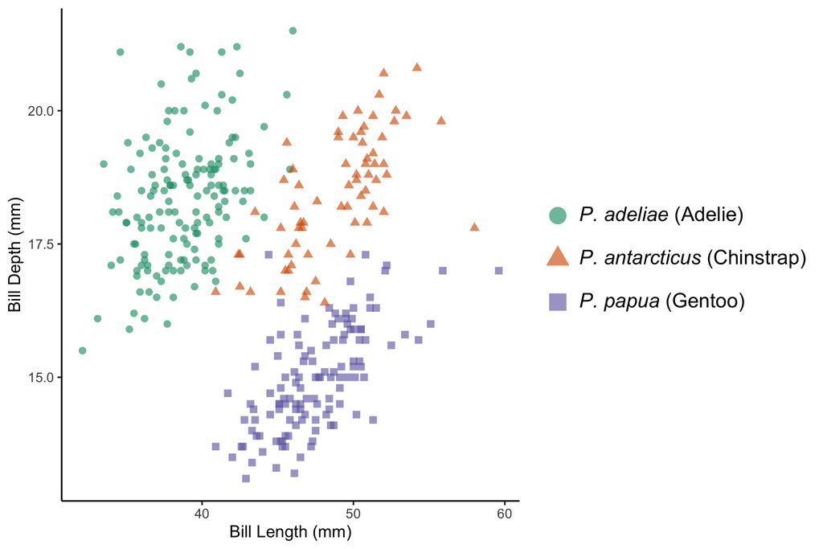

Figure 2: Subplot 1.

## Subplot 2

Description: A distribution plot comparing the distributions of “bill ratio”, a derived variable calculated as the ratio of bill depth to bill length.

Key tweaks:

- Uses `stat_dotsinterval` geom from the `ggdist` package
- Legend suppressed
- Species names placed in the figure itself using `ggtext::geom_richtext()`
- Y-axis lines and ticks removed

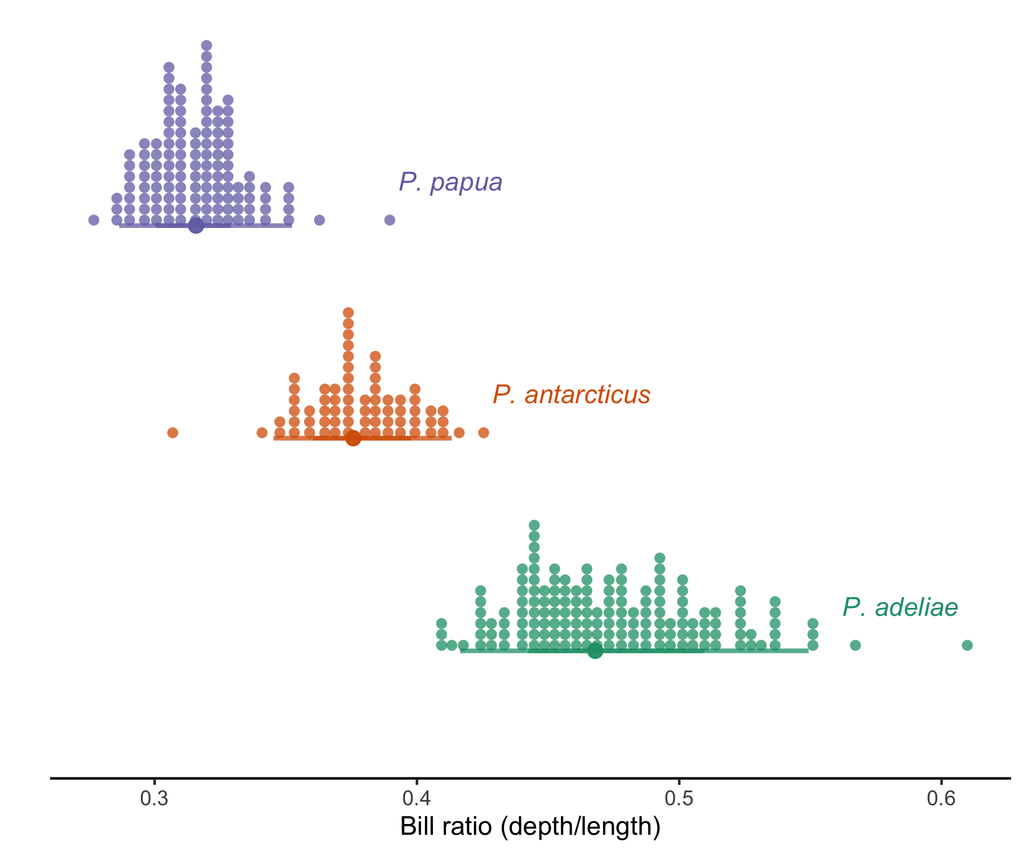

Figure 3: Subplot 2.

## Subplot 3

Description: Violin plots comparing the distribution of “bill ratio” between female and male penguins, faceted by species.

Key tweaks:

- Removed the `strip` names created by the faceting
- Removed the default legend (redundant with the facet names)
- Moved species names into the body of the figure using `ggtext::geom_richtext()`

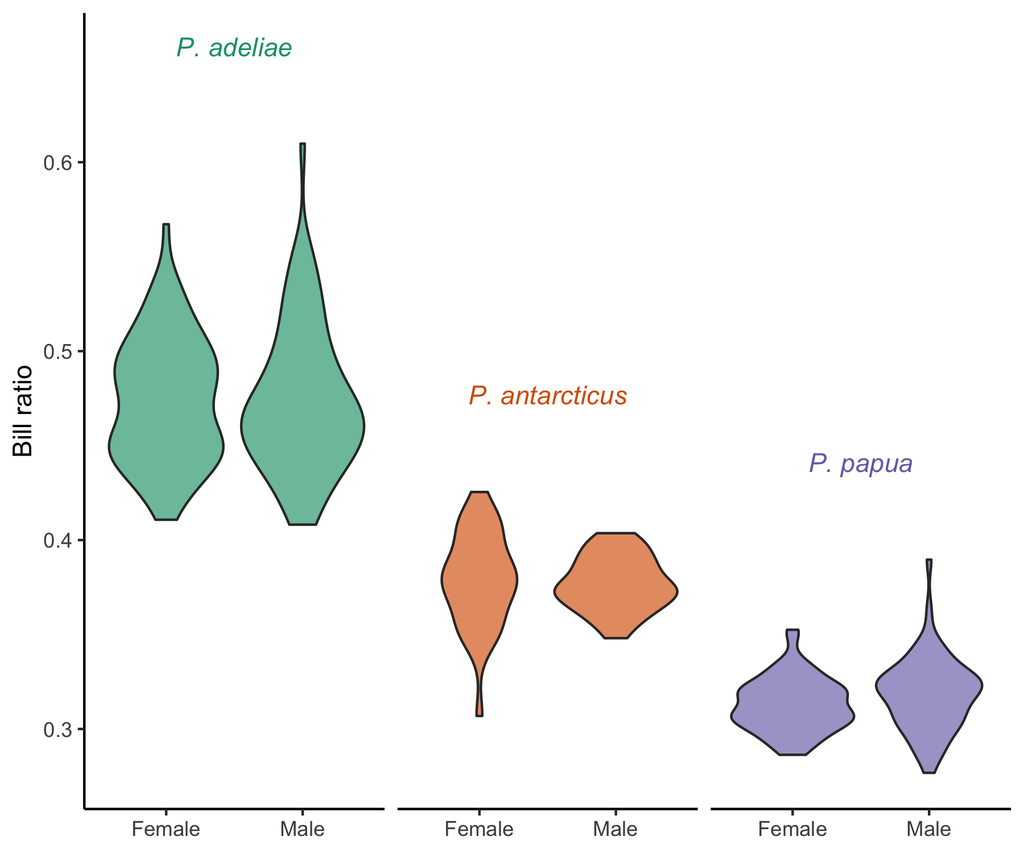

Figure 4: Subplot 3.

## Multi-plot layout

Key tweaks:

- Using the `magick` package, load an image file – this [penguin illustration](https://allisonhorst.github.io/palmerpenguins/reference/figures/culmen_depth.png) from the palmerpenguins web site
- Use the `patchwork` package to define the layout of the subplots, the image, and the “shared” legend
- Save the image to high resolution PNG and PDF using `ggsave()`